**Jupyter Kernel for MATLAB**

By Prof. Seungchul Lee  
http://iai.postech.ac.kr/  
Industrial AI Lab at POSTECH

Table of Contents

# 1. Overview

- 내용
  - 본 매뉴얼은 **Jupyter notebook**의 **Matlab** 을 위한 패키지 설치를 다룸
- OS
  - 사용자 편의를 위해 Windows 10으로 매뉴얼 작성
- Anaconda
  - 본 메뉴얼에서는 패키지들 사이의 충돌을 방지하기 위해 Anaconda를 사용하지 않음

# 2. Requirements

- Windows 10, 64 bits PC (recommended)
- Python
- Visual C++ 2015 Redistributable (or 2017)
- Matlab

# 3. Matlab Kernel Installation

- Python용 Matlab Engine API 설치하기

  [1] cmd 관리자모드 실행

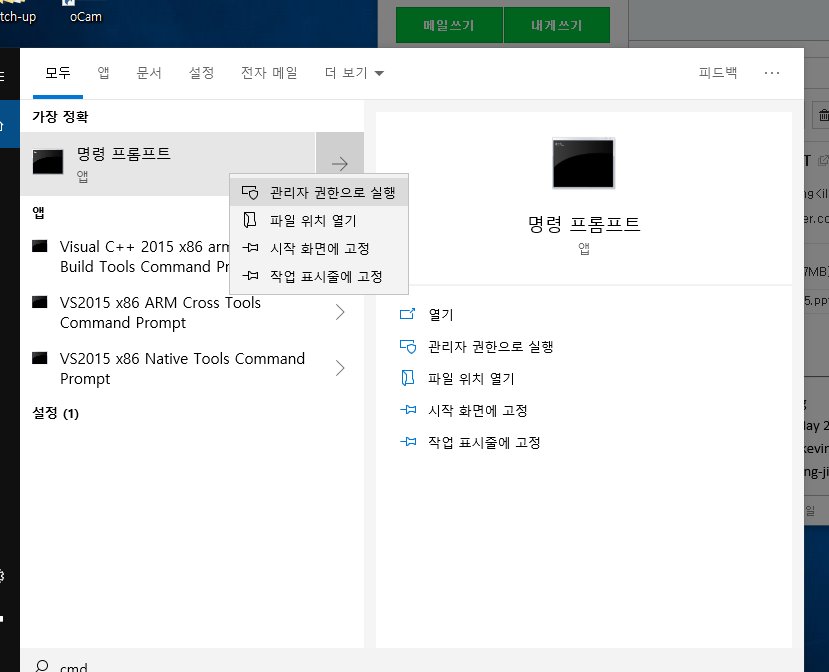

[2] `Matlab이 설치된 경로/extern/engines/python`로 경로 변경

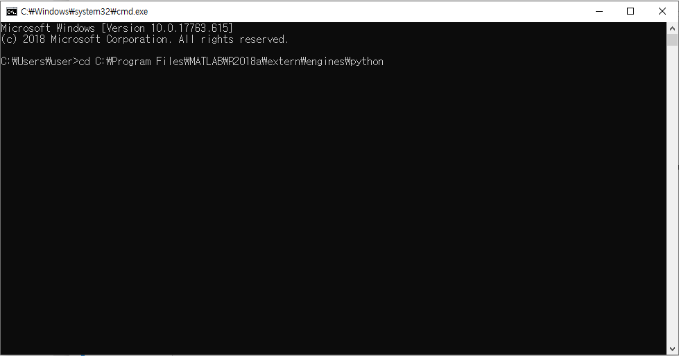

[3] `python setup.py install` 입력

[figure not shown]

- Matlab Kernel 설치하기

  [4] `pip install matlab_kernel` 입력

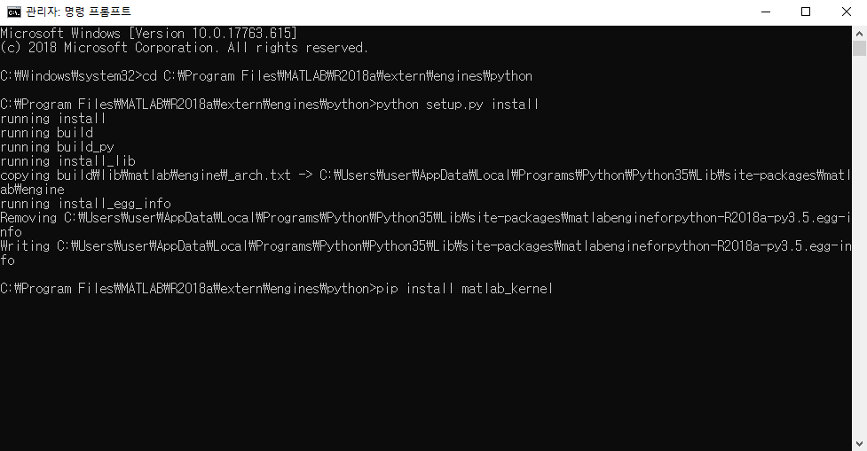

# 4. Setup Validation

- Matlab Jupyter Notebook 생성

  [1] 폴더 주소창에 jupyter notebook 입력

  [2] New 클릭 후

  [3] Matlab 선택

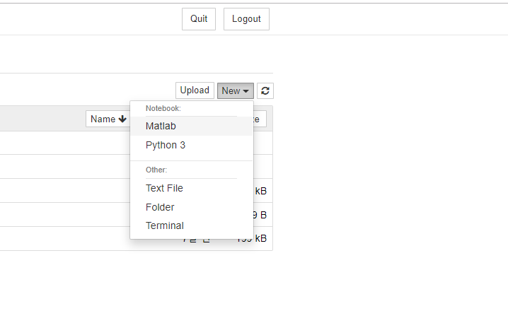

- 코드 실행

  [4] 아래와 같이 코드 입력 후 실행.

  $\;\;\;\;$셀 입력 후 버튼 클릭 또는 ctrl + enter 로 실행 가능

```matlab
tx = linspace(-8, 8, 41);
ty = tx;
[xx, yy] = meshgrid(tx, ty);
r = sqrt(xx.^2 + yy.^2) + eps;
tz = sin(r)./r;
```

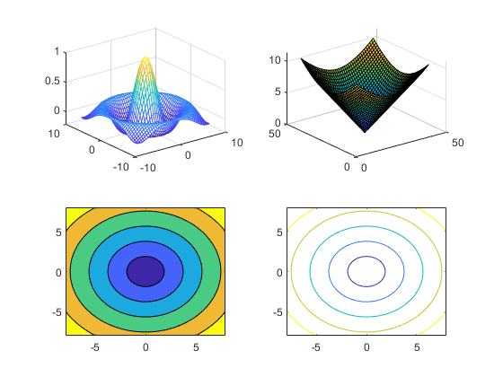

```matlab
subplot(2,2,1)
mesh(tx, ty, tz);
subplot(2,2,2)
surf(r)
subplot(2,2,3)
contourf(xx, yy, r, 5)
subplot(2,2,4)
contour(xx, yy, r, 5)
```

# 5. 문의

- 설치에 어려움이 있으신 분들은 (반드시) 연락 바랍니다
  - 이승철 교수 (seunglee@postech.ac.kr)

```matlab
%%javascript
$.getScript('https://kmahelona.github.io/ipython_notebook_goodies/ipython_notebook_toc.js')
```